[OHI Science](http://ohi-science.org) | [Citation policy](http://ohi-science.org/citation-policy/)

# OHI 2017: Sea Level Rise Pressure Layer

Compiled on Thu Aug 24 14:44:54 2017 by afflerbach

# Summary

This layer preparation script does the following for newly available SLR data.

- Clips all monthly rasters to the coast using a 3 nautical mile offshore buffer
- Calculates annual mean sea level anomaly rasters from monthly data
- Rescales values from 0 to 1 using the reference point
- Sets to zero all negative values, indicating decreases in mean sea level
- Resamples raster to ~ 1km<sup>2</sup> and reproject to Molleweide

This process is completed entirely within this script. The raw data is downloaded externally and held on a server at NCEAS. Although the raw data is not provided, this script can be used on the data downloaded from Aviso [here](http://www.aviso.altimetry.fr/en/data/products/sea-surface-height-products/global/msla-mean-climatology.html). You will need to register with Aviso in order to get a username and password for data access.

# Updates from previous assessment

One additional year of data, 2016, was added. In addition we are using a better mask to eliminate cells farther than 3nm offshore. This change requires a rerun of all year within the dataset.

# Data

The source data are monthly mean sea level anomalies, in meters. These anomalies are calculated by subtracting the current absolute sea level for each month from the average sea level for that month calculated from 1993 - 2012.

**Reference**: The altimeter products were produced and distributed by Aviso (http://www.aviso.altimetry.fr/), as part of the Ssalto ground processing segment. [AVISO MSLA heights, monthly means](http://www.aviso.altimetry.fr/en/data/products/sea-surface-height-products/global/msla-mean-climatology.html)  
**Downloaded**: August 1, 2017 (for 2016 data)  
**Description**: Monthly mean sea level anomaly (meters above mean sea level)  
**Native data resolution**: 0.25 degree grid cells  
**Time range**: January 1993 - December 2016  
**Format**: NetCDF

# Methods

## Setup

```r
knitr::opts_chunk$set(fig.width = 6, fig.height = 4, fig.path = 'figs/',message = FALSE, warning = FALSE)

#setting up provenance
# devtools::install_github('oharac/provRmd')
# library(provRmd)
# prov_setup()

library(tidyverse)
library(raster)
library(RColorBrewer)
library(maps)
library(parallel)
library(foreach)
library(doParallel)

#define github file path
dir_git <- '~/github/ohiprep'

source('~/github/ohiprep/src/R/common.R')

#define server file path
dir_anx <- file.path(dir_M, 'git-annex/globalprep')

#define raw data file path (non-NCEAS folks will not have access to this data)
dir_anx_aviso <- file.path(dir_M, 'git-annex/globalprep/_raw_data/AVISO_slr')

### set up proj4string options: WGS84
p4s_wgs84 <- '+proj=longlat +datum=WGS84 +no_defs +ellps=WGS84 +towgs84=0,0,0'

### Define spectral color scheme for plotting maps
cols      = rev(colorRampPalette(brewer.pal(9, 'Spectral'))(255)) # rainbow color scheme

# define mollweide projection
mollCRS <- CRS('+proj=moll')

# Read in ocean raster with cells at 1km. Use this as a template for resampling. This is held on an NCEAS server and folks without access will not be able to use this mask.
ocean = raster(file.path(dir_M, 'git-annex/globalprep/spatial/ocean.tif'))
```

## Data Prep

### Clip data to coastal cells

All NetCDF files for each month are rasterized and all non-coastal bordering cells are removed. To do this we use a 3 nautical mile offshore buffer polygon to select all coastal cells. For this to work, the raw data cells need to be disaggregated by a factor of 8 in order for the mask to accurately select cells that fall within the polygons.

```r
#list all netCDF files
nc_files <- c(list.files(file.path(dir_anx_aviso, 'd2017'),
                       full.names = TRUE, pattern = '.nc'),
              list.files(file.path(dir_anx_aviso, 'd2016/msla_monthly_mean'),
                      full.names = TRUE, pattern = '.nc'))
```

The raw monthly data looks like this:

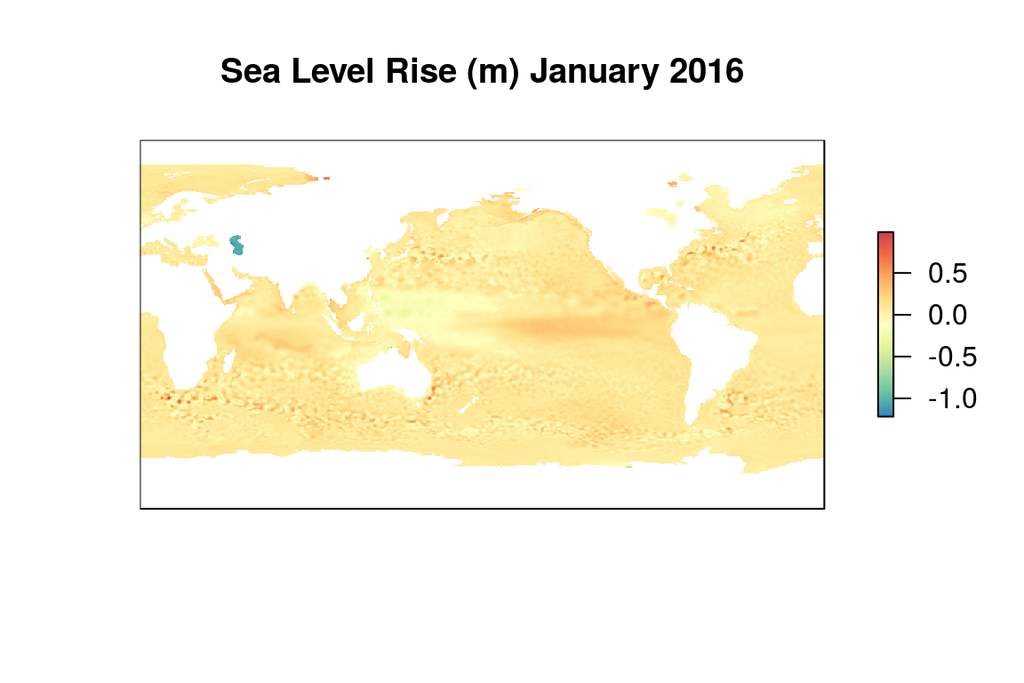

```r
plot(raster(nc_files[1]),col=cols,axes=F, main = "Sea Level Rise (m) January 2016")
```

Since we are only interested in the increase in sea level near the coasts, we apply a mask to the raster layers that removes all cells farther than 3nm offshore. This mask was created previously for the OHI global 2016 assessment.

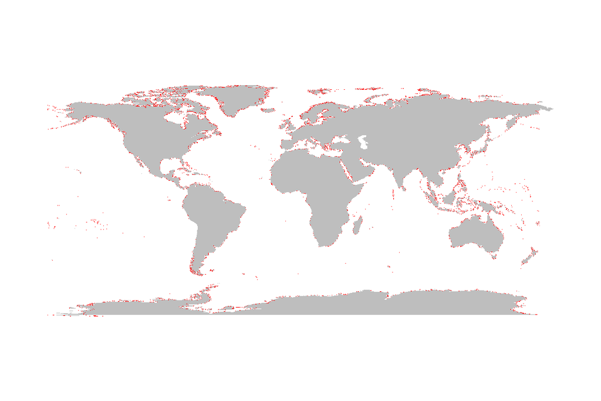

```r
## 3nm offshore raster to select only nearshore cells.
s <- raster(file.path(dir_git,'globalprep/prs_slr/v2016/int/rast_3nm_mask_fasterize.tif'))
maps::map("world",fill=TRUE,col = "gray",border = NA)
plot(s,col='red',add=T,legend=F)
```

A function `months_coast` was written to:

1. Rasterize each monthly NetCDF file
2. Rotate each raster so that the Atlantic Ocean is centered in the raster
3. Disaggregate the cell resolution by a factor of 8 in order to have a fine enough resolution for the mask to keep cells nearshore
4. And then apply the 3nm mask

The output is saved in the folder `int/msla_monthly_coast`

```r
registerDoParallel(10)

## parallel forloop function that rotates each monthly file, sets the long/lat projection, and keeps only coastal cells - saved to GitHub

foreach(file = nc_files) %dopar% {

  m_yr <- substr(file,nchar(file)-10,nchar(file)-3)

  #read in month raster
   r <- raster(file)%>%
          rotate()%>%
        disaggregate(fact = 8)

  #define projection of the raster before reprojecting
  projection(r) <- "+proj=longlat +datum=WGS84 +ellps=WGS84 +towgs84=0,0,0"

  r_mask <- mask(r,s,progress='text')

  writeRaster(r_mask,filename=paste0(dir_git,'/globalprep/prs_slr/v2017/int/msla_monthly_coast/msla_monthly_coast_',m_yr,'.tif'),overwrite=T)

}
```

## Annual mean sea level anomalies

Annual mean sea level anomaly rasters are calculated from the monthly data.

```r
msla_files <- list.files(file.path(dir_git, 'globalprep/prs_slr/v2017/int/msla_monthly_coast'), full.names=T)

## stack all rasters for this year, and calc annual mean, then write as raster

registerDoParallel(6)

foreach(yr = c(1993:2016)) %dopar%{

  files = msla_files[str_detect(msla_files, as.character(yr))]

  rast_annual_mean <- stack(files)%>%
                      calc(mean, na.rm=T)%>%
                      writeRaster(filename = paste0(file.path(dir_git),
                                                    '/globalprep/prs_slr/v2017/int/msla_annual_mean/rast_msla_annual_',yr,'.tif'), overwrite=T)
}
```

## Reference Point

The reference point is the 99.99th quantile of the entire data distribution from 1993 - 2015. We will use the [same reference point](https://github.com/OHI-Science/ohiprep/blob/master/globalprep/supplementary_information/v2016/reference_points_pressures.csv) that was used in previous global assessments: 0.246225 m.

```r
annual_means <- list.files(file.path(dir_git, 'globalprep/prs_slr/v2017/int/msla_annual_mean'), pattern = '*.tif', full.names=T)

ref <- read_csv(file.path(dir_git, 'globalprep/supplementary_information/v2016/reference_points_pressures.csv'))%>% #grab reference value from the supp_info csv
       filter(pressure == "Sea Level Rise")%>%
       .$ref_point%>%
        as.numeric()
```

## Rescale

Each annual raster is recaled from 0 to 1 using the reference point. If a value is greater than the reference point, it is automatically given a value of 1.

```r
foreach(file = annual_means) %dopar%{

  yr <- substr(file, 96,99)
    raster(file)%>%
      calc(fun=function(x){ifelse(x<0,0,x)})%>% #set all negative values to 0
      calc(fun=function(x){ifelse(x>ref,1,x/ref)})%>%
      projectRaster(crs = mollCRS,over=T)%>%
      resample(ocean,method = 'ngb', filename = paste0(file.path(dir_anx),'/prs_slr/v2017/output/slr_',yr,'.tif'),overwrite=T)

}
```

# Results

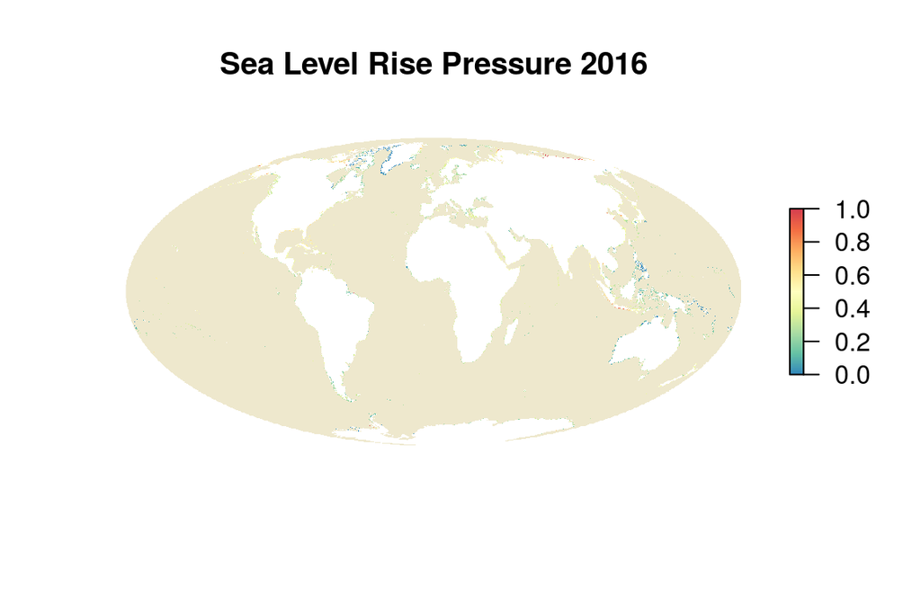

```r
r <- raster(file.path(dir_anx,'prs_slr/v2017/output/slr_2016.tif'))

plot(ocean, col='cornsilk2', axes=F, box=F, main='Sea Level Rise Pressure 2016', legend=F)
plot(r,col=cols,axes=F,box=F,add=T)
```

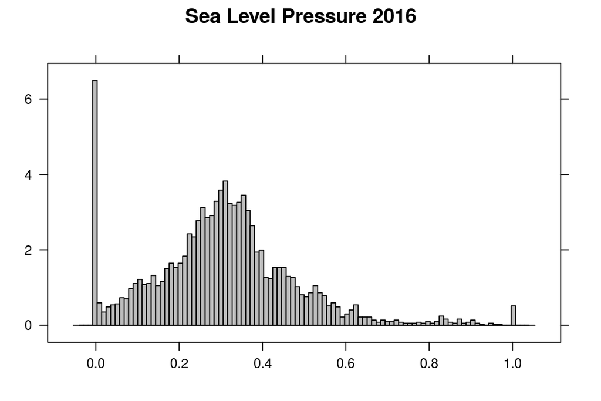

```r
rasterVis::histogram(r, main ='Sea Level Pressure 2016')
```

### Citation information

The altimeter products were produced and distributed by Aviso (http://www.aviso.altimetry.fr/), as part of the Ssalto ground processing segment. [AVISO MSLA heights, monthly means](http://www.aviso.altimetry.fr/en/data/products/sea-surface-height-products/global/msla-mean-climatology.html)